# Untitled

Aaron Watt

2/17/2022

# Using the EPA Air Quality System (AQS) API to get pollution data

Our goal is to download data for Berkeley’s PM2.5 pollution and map it.

## Packages

```r
# install.packages(c("httr", "jsonlite"))
library(httr)
library(jsonlite)
```

1. We need to setup an account with the AQS API. We can do this through the API

```r
email = "aaron@acwatt.net"
url = paste0("https://aqs.epa.gov/data/api/signup?email=", email)
result = GET(url)
```

```r
# print result -- fairly nice looking
result
```

```
## Response [https://aqs.epa.gov/data/api/signup?email=aaron@acwatt.net]
##   Date: 2022-02-17 20:25
##   Status: 200
##   Content-Type: application/json; charset=utf-8
##   Size: 269 B
## {
##   "Header": [
##     {
##       "status": "Success",
##       "request_time": "2022-02-17T15:25:34-05:00",
##       "url": "https://aqs.epa.gov/data/api/signup?email=aaron@acwatt.net"
##     }
##   ],
##   "Data": [
##     "You should receive an email containing your new key shortly."
## ...
```

```r
# print actual content -- unicode
result$content
```

```
##   [1] 7b 0a 20 20 22 48 65 61 64 65 72 22 3a 20 5b 0a 20 20 20 20 7b 0a 20 20 20
##  [26] 20 20 20 22 73 74 61 74 75 73 22 3a 20 22 53 75 63 63 65 73 73 22 2c 0a 20
##  [51] 20 20 20 20 20 22 72 65 71 75 65 73 74 5f 74 69 6d 65 22 3a 20 22 32 30 32
##  [76] 32 2d 30 32 2d 31 37 54 31 35 3a 32 35 3a 33 34 2d 30 35 3a 30 30 22 2c 0a
## [101] 20 20 20 20 20 20 22 75 72 6c 22 3a 20 22 68 74 74 70 73 3a 2f 2f 61 71 73
## [126] 2e 65 70 61 2e 67 6f 76 2f 64 61 74 61 2f 61 70 69 2f 73 69 67 6e 75 70 3f
## [151] 65 6d 61 69 6c 3d 61 61 72 6f 6e 40 61 63 77 61 74 74 2e 6e 65 74 22 0a 20
## [176] 20 20 20 7d 0a 20 20 5d 2c 0a 20 20 22 44 61 74 61 22 3a 20 5b 0a 20 20 20
## [201] 20 22 59 6f 75 20 73 68 6f 75 6c 64 20 72 65 63 65 69 76 65 20 61 6e 20 65
## [226] 6d 61 69 6c 20 63 6f 6e 74 61 69 6e 69 6e 67 20 79 6f 75 72 20 6e 65 77 20
## [251] 6b 65 79 20 73 68 6f 72 74 6c 79 2e 22 0a 20 20 5d 0a 7d
```

```r
# Translate from unicode to human-readable (turns out it's JSON)
rawToChar(result$content)
```

```
## [1] "{\n  \"Header\": [\n    {\n      \"status\": \"Success\",\n      \"request_time\": \"2022-02-17T15:25:34-05:00\",\n      \"url\": \"https://aqs.epa.gov/data/api/signup?email=aaron@acwatt.net\"\n    }\n  ],\n  \"Data\": [\n    \"You should receive an email containing your new key shortly.\"\n…
```

```r
# Translate from JSON (named list)
output <- fromJSON(rawToChar(result$content))

# Get the data
output$Data
```

```
## [1] "You should receive an email containing your new key shortly."
```

Take a look at the “Status” part of the response (200). What does this mean?

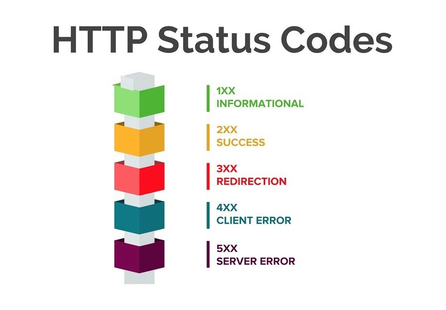

HTTP status codes

## Get a list of air quality monitors in Alameda county

The API instructions tell us this is the type of URL we need to request to get a list of monitors in a county: `https://aqs.epa.gov/data/api/monitors/byCounty?email=test@aqs.api&key=test&param=42401&bdate=20150501&edate=20150502&state=15&county=003`

Let’s break this up: `https://aqs.epa.gov/data/api/monitors/byCounty`…  
…`?email=test@aqs.api`  
…`&key=test`  
…`&param=42401`  
…`&bdate=20150501`  
…`&edate=20150502`  
…`&state=15`  
…`&county=003`

### What is this requesting?

```r
cali_fips = "06"
alameda_fips = "001"
"https://aqs.epa.gov/data/api/monitors/byCounty?email=test@aqs.api&key=test&param=42401&bdate=20150501&edate=20150502&state=15&county=056"
```

```
## [1] "https://aqs.epa.gov/data/api/monitors/byCounty?email=test@aqs.api&key=test&param=42401&bdate=20150501&edate=20150502&state=15&county=056"
```

## Helpful links:

EPA AQS API Doc:  
[`https://aqs.epa.gov/aqsweb/documents/data_api.html`](https://aqs.epa.gov/aqsweb/documents/data_api.html)

Parameter classes:  
[`https://aqs.epa.gov/data/api/list/classes?email=test@aqs.api&key=test`](https://aqs.epa.gov/data/api/list/classes?email=test@aqs.api&key=test)

Parameters in Criteria pollutant class:  
[`https://aqs.epa.gov/data/api/list/parametersByClass?email=test@aqs.api&key=test&pc=CRITERIA`](https://aqs.epa.gov/data/api/list/parametersByClass?email=test@aqs.api&key=test&pc=CRITERIA)